# Proj2

Project: Predicting Potential Customers

**Phillipe Vilaça Gomes**

- phillipe.vilaca@gmail.com
- https://www.linkedin.com/in/phillipegomes/
- https://scholar.google.com/citations?user=xY6VjEUAAAAJ&hl=en

## Table of Content

**1. Problem Definition**  
**1.1 The Context**  
**1.2 The Objectives**  
**2. Exploratory Data Analysis (EDA) and Visualization**  
**2.1 Data Dictionary**  
**2.2 Data Description**  
**2.3 Univariate Analysis - Numerical Data**  
**2.4 Bivariate Analysis**  
**2.5 Multivariate Analysis**  
**2.6 Summary of Notes**  
**3. Proposed Approach**  
**3.1 Potential Techniques**  
**3.2 Overall solution design**  
**3.3 Measures of success**  
**4. Model Building**  
**4.1 Data preparation**  
**4.2 Model Evaluation Function**  
**5. Decision Tree (DT) Model**  
**5.1 DT with Default Hyperparameters**  
**5.2 DT with Tuned Hyperparameters**  
**6. Random Forest (RF) Model**  
**6.1 RF with Default Hyperparameters**  
**6.2 RF with Tuned Hyperparameters**  
**7. Comparing Model Performances**  
**8. Conclusion and Busines Recommendations**

1. Problem Definition

1.1 The context

The EdTech industry has been surging in the past decade immensely, and according to a forecast, the Online Education market, would be worth $286.62bn by 2023, with a compound annual growth rate (CAGR) of 10.26% from 2018 to 2023. The modern era of online education has enforced a lot in its growth and expansion beyond any limit. Due to having many dominant features like ease of information sharing, personalized learning experience, transparency of assessment, etc., it is now preferable to traditional education.

The online education sector has witnessed rapid growth and is attracting a lot of new customers. Due to this rapid growth, many new companies have emerged in this industry. With the availability and ease of use of digital marketing resources, companies can reach out to a wider audience with their offerings. The customers who show interest in these offerings are termed as leads. There are various sources of obtaining leads for Edtech companies, like:

- The customer interacts with the marketing front on social media or other online platforms.
- The customer browses the website/app and downloads the brochure.
- The customer connects through emails for more information.

The company then nurtures these leads and tries to convert them to paid customers. For this, the representative from the organization connects with the lead on call or through email to share further details.

1.2 The objectives

ExtraaLearn is an initial stage startup that offers programs on cutting-edge technologies to students and professionals to help them upskill/reskill. With a large number of leads being generated on a regular basis, one of the issues faced by ExtraaLearn is to identify which of the leads are more likely to convert so that they can allocate the resources accordingly. You, as a data scientist at ExtraaLearn, have been provided the leads data to:

- Analyze and build an ML model to help identify which leads are more likely to convert to paid customers.
- Find the factors driving the lead conversion process.
- Create a profile of the leads which are likely to convert.

2. Exploratory Data Analysis (EDA) and Visualization

**Importing libraries**

```python
# Scientific Computing
import numpy as np

# Data Analysis
import pandas as pd

# Plotting
from matplotlib import pyplot as plt
%matplotlib inline
plt.style.use('ggplot')

# Statistical Data Visualization
import seaborn as sns

# Efficient tools for machine learning and statistical modeling
from sklearn import tree

# To scale the data using z-score
from sklearn.preprocessing import StandardScaler

# To split matrices into random train and test subsets
from sklearn.model_selection import train_test_split

# Algorithms to use
from sklearn import tree
from sklearn.tree import DecisionTreeClassifier
from sklearn.ensemble import RandomForestClassifier
from sklearn.linear_model import LogisticRegression

# Metrics to evaluate the model
from sklearn import metrics
from sklearn.metrics import confusion_matrix, classification_report, recall_score, precision_score, accuracy_score, precision_recall_curve

# For tuning the model
from sklearn.model_selection import GridSearchCV

# To ignore warnings
import warnings
warnings.filterwarnings("ignore")
```

2.1 Data Dictionary

The data contains the different attributes of leads and their interaction details with ExtraaLearn. The detailed data dictionary is given below.

- **ID**: ID of the lead
- **age**: Age of the lead
- **current_occupation**: Current occupation of the lead. Values include 'Professional', 'Unemployed', and 'Student'
- **first_interaction**: How did the lead first interact with ExtraaLearn? Values include 'Website' and 'Mobile App'
- **profile_completed**: What percentage of the profile has been filled by the lead on the website/mobile app? Values include Low - (0-50%), Medium - (50-75%), High (75-100%)
- **website_visits**: The number of times a lead has visited the website
- **time_spent_on_website**: Total time (seconds) spent on the website.
- **page_views_per_visit**: Average number of pages on the website viewed during the visits
- **last_activity**: Last interaction between the lead and ExtraaLearn
  - **Email Activity**: Seeking details about the program through email, Representative shared information with a lead like a brochure of the program, etc.
  - **Phone Activity**: Had a phone conversation with a representative, had a conversation over SMS with a representative, etc.
  - **Website Activity**: Interacted on live chat with a representative, updated profile on the website, etc.
- **print_media_type1**: Flag indicating whether the lead had seen the ad of ExtraaLearn in the Newspaper
- **print_media_type2**: Flag indicating whether the lead had seen the ad of ExtraaLearn in the Magazine
- **digital_media**: Flag indicating whether the lead had seen the ad of ExtraaLearn on the digital platforms
- **educational_channels**: Flag indicating whether the lead had heard about ExtraaLearn in the education channels like online forums, discussion threads, educational websites, etc.
- **referral**: Flag indicating whether the lead had heard about ExtraaLearn through reference.
- **status**: Flag indicating whether the lead was converted to a paid customer or not. The class 1 represents the paid customer and class 0 represents the unpaid customer.

2.2 Data Description

**Read the dataset**

```python
hm=pd.read_csv("ExtraaLearn.csv")
```

**Copying data to another variable to avoid any changes to the original data**

```python
data=hm.copy()
```

**Displaying first and last five rows**

```python
data
```

|  | ID | age | current_occupation | first_interaction | profile_completed | website_visits | time_spent_on_website | page_views_per_visit | last_activity | print_media_type1 | print_media_type2 | digital_media | educational_channels | referral | status |
| --- | --- | --- | --- | --- | --- | --- | --- | --- | --- | --- | --- | --- | --- | --- | --- |
| 0 | EXT001 | 57 | Unemployed | Website | High | 7 | 1639 | 1.861 | Website Activity | Yes | No | Yes | No | No | 1 |
| 1 | EXT002 | 56 | Professional | Mobile App | Medium | 2 | 83 | 0.320 | Website Activity | No | No | No | Yes | No | 0 |
| 2 | EXT003 | 52 | Professional | Website | Medium | 3 | 330 | 0.074 | Website Activity | No | No | Yes | No | No | 0 |
| 3 | EXT004 | 53 | Unemployed | Website | High | 4 | 464 | 2.057 | Website Activity | No | No | No | No | No | 1 |
| 4 | EXT005 | 23 | Student | Website | High | 4 | 600 | 16.914 | Email Activity | No | No | No | No | No | 0 |
| ... | ... | ... | ... | ... | ... | ... | ... | ... | ... | ... | ... | ... | ... | ... | ... |
| 4607 | EXT4608 | 35 | Unemployed | Mobile App | Medium | 15 | 360 | 2.170 | Phone Activity | No | No | No | Yes | No | 0 |
| 4608 | EXT4609 | 55 | Professional | Mobile App | Medium | 8 | 2327 | 5.393 | Email Activity | No | No | No | No | No | 0 |
| 4609 | EXT4610 | 58 | Professional | Website | High | 2 | 212 | 2.692 | Email Activity | No | No | No | No | No | 1 |
| 4610 | EXT4611 | 57 | Professional | Mobile App | Medium | 1 | 154 | 3.879 | Website Activity | Yes | No | No | No | No | 0 |
| 4611 | EXT4612 | 55 | Professional | Website | Medium | 4 | 2290 | 2.075 | Phone Activity | No | No | No | No | No | 0 |

4612 rows × 15 columns

**Understanding the shape of the dataset**

```python
data.shape
```

```
(4612, 15)
```

**Checking the data types of the columns in the dataset**

```python
data.info()
```

```
<class 'pandas.core.frame.DataFrame'>
RangeIndex: 4612 entries, 0 to 4611
Data columns (total 15 columns):
 #   Column                 Non-Null Count  Dtype
---  ------                 --------------  -----
 0   ID                     4612 non-null   object
 1   age                    4612 non-null   int64
 2   current_occupation     4612 non-null   object
 3   first_interaction      4612 non-null   object
 4   profile_completed      4612 non-null   object
 5   website_visits         4612 non-null   int64
 6   time_spent_on_website  4612 non-null   int64
 7   page_views_per_visit   4612 non-null   float64
 8   last_activity          4612 non-null   object
 9   print_media_type1      4612 non-null   object
 10  print_media_type2      4612 non-null   object
 11  digital_media          4612 non-null   object
 12  educational_channels   4612 non-null   object
 13  referral               4612 non-null   object
 14  status                 4612 non-null   int64
dtypes: float64(1), int64(4), object(10)
memory usage: 540.6+ KB
```

**Observations**:

- The dataset has 4612 rows and 15 columns.
- `age`, `website_visits`, `time_spent_on_website`, `page_views_per_visit`, and `status` are of numeric type while rest of the columns are of object type.
- There are no null values in the dataset

**Checking for duplicate values**

```python
data.duplicated().sum()
```

```
0
```

**Summary Statistics of the dataset for numerical variables**

```python
# Creating numerical columns
num_cols = ['age', 'website_visits', 'time_spent_on_website', 'page_views_per_visit', 'status']
# Checking summary statistics for numerical columns
data[num_cols].describe().T
```

|  | count | mean | std | min | 25% | 50% | 75% | max |
| --- | --- | --- | --- | --- | --- | --- | --- | --- |
| age | 4612.0 | 46.201214 | 13.161454 | 18.0 | 36.00000 | 51.000 | 57.00000 | 63.000 |
| website_visits | 4612.0 | 3.566782 | 2.829134 | 0.0 | 2.00000 | 3.000 | 5.00000 | 30.000 |
| time_spent_on_website | 4612.0 | 724.011275 | 743.828683 | 0.0 | 148.75000 | 376.000 | 1336.75000 | 2537.000 |
| page_views_per_visit | 4612.0 | 3.026126 | 1.968125 | 0.0 | 2.07775 | 2.792 | 3.75625 | 18.434 |
| status | 4612.0 | 0.298569 | 0.457680 | 0.0 | 0.00000 | 0.000 | 1.00000 | 1.000 |

**Observations**:

**Summary Statistics of the dataset for categorical variables**

```python
# Making a list of all categorical variables
cat_col = list(data.select_dtypes("object").columns)

# Printing count of each unique value in each categorical column
for column in cat_col:
    print(data[column].value_counts(normalize = True))
    print("-" * 50)
```

```
EXT001     0.000217
EXT2884    0.000217
EXT3080    0.000217
EXT3079    0.000217
EXT3078    0.000217
             ...
EXT1537    0.000217
EXT1536    0.000217
EXT1535    0.000217
EXT1534    0.000217
EXT4612    0.000217
Name: ID, Length: 4612, dtype: float64
--------------------------------------------------
Professional    0.567216
Unemployed      0.312446
Student         0.120338
Name: current_occupation, dtype: float64
--------------------------------------------------
Website       0.551171
Mobile App    0.448829
Name: first_interaction, dtype: float64
--------------------------------------------------
High      0.490893
Medium    0.485906
Low       0.023200
Name: profile_completed, dtype: float64
--------------------------------------------------
Email Activity      0.493929
Phone Activity      0.267563
Website Activity    0.238508
Name: last_activity, dtype: float64
--------------------------------------------------
No     0.892238
Yes    0.107762
Name: print_media_type1, dtype: float64
--------------------------------------------------
No     0.94948
Yes    0.05052
Name: print_media_type2, dtype: float64
--------------------------------------------------
No     0.885733
Yes    0.114267
Name: digital_media, dtype: float64
--------------------------------------------------
No     0.847138
Yes    0.152862
Name: educational_channels, dtype: float64
--------------------------------------------------
No     0.979835
Yes    0.020165
Name: referral, dtype: float64
--------------------------------------------------
```

**Observations**:

- Most of the leads are working professionals.
- As expected, the majority of the leads interacted with ExtraaLearn from the website.
- Almost an equal percentage of profile completions are categorized as high and medium that is 49.1% and 48.6%, respectively. Only **2.3%** of the profile completions are categorized as low.
- Approx 49.4% of the leads had their last activity over email, followed by 26.8% having phone activity. This implies that the majority of the leads prefer to communicate via email.
- We can observe that each ID has an equal percentage of values. Let's check the number of unique values in the ID column.

```python
# Checking the number of unique values
data["ID"].nunique()
```

```
4612
```

**Observations**:

- All the values in the ID column are unique.
- We can drop this column as it would not add value to our analysis.

```python
# Dropping ID column
data.drop(["ID"], axis = 1, inplace = True)
```

**Checking the balance of the status, the target**

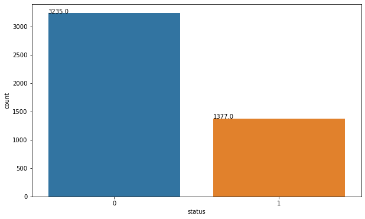

```python
plt.figure(figsize = (10, 6))

ax = sns.countplot(x = 'status', data = data)

# Annotating the exact count on the top of the bar for each category
for p in ax.patches:
    ax.annotate('{:.1f}'.format(p.get_height()), (p.get_x(), p.get_height()+ 0.35))
```

**Observations**:

- The above plot shows that number of leads converted are significantly less than number of leads not converted which can be expected.
- The plot indicates that **~30%** (1377/4612) of leads have been converted.

2.3 Univariate Analysis - Numerical Data

```
age
Skew : -0.72
```

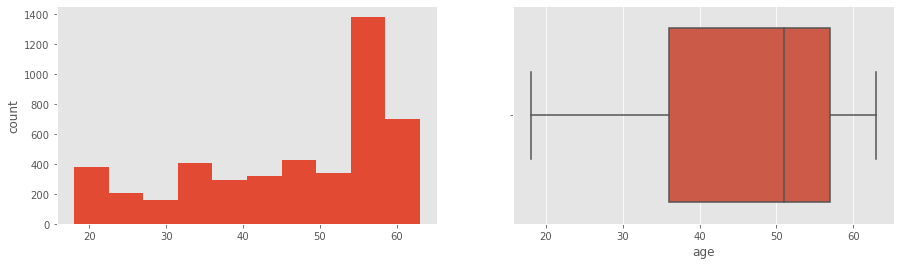

```
website_visits
Skew : 2.16
```

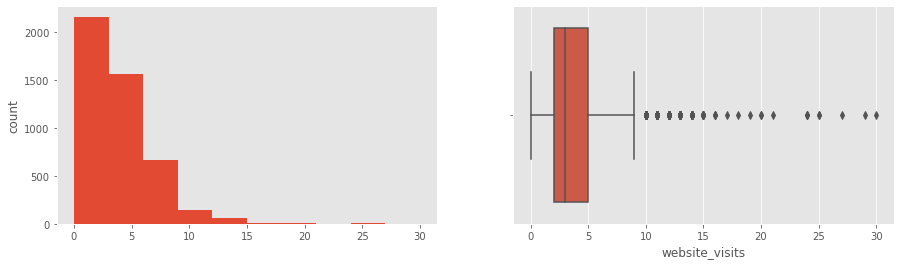

```
time_spent_on_website
Skew : 0.95
```

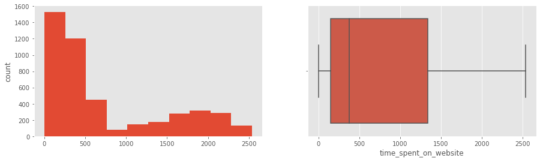

```
page_views_per_visit
Skew : 1.27
```

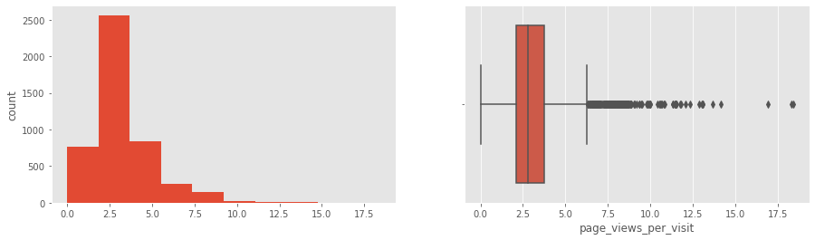

```python
for col in ['age', 'website_visits', 'time_spent_on_website', 'page_views_per_visit']:
    print(col)

    print('Skew :',round(data[col].skew(), 2))

    plt.figure(figsize = (15, 4))

    plt.subplot(1, 2, 1)

    data[col].hist(bins = 10, grid = False)

    plt.ylabel('count')

    plt.subplot(1, 2, 2)

    sns.boxplot(x = data[col])

    plt.show()
```

**Observations**:

- the variable **age** has a left-skewed distribution, meaning most leads has ages concentrated on the right side (closer to the the maximum value) of the distribution graph while the left tail of the distribution graph is longer.
- The **website_visits** distribution is skewed to the right, which means leads are mostly visiting the website a few number of times.
- The **time_spent_on_website** distribution is also skewed to the right, but it has two peaks, one higher at 0 (~1500 observations) and another lower at 2000 (~400 observations).
- The variable **page_views_per_visit** has a right-skewed distribution, meaning most leads have only given a few clicks.

2.4 Bivariate Analysis

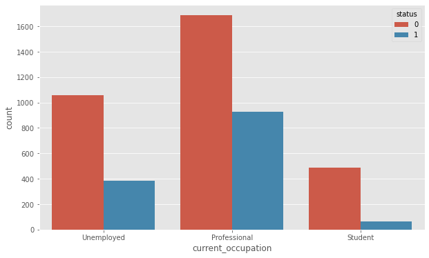

```python
plt.figure(figsize = (10, 6))

sns.countplot(x = 'current_occupation', hue = 'status', data = data)

plt.show()
```

**Observations**:

- The plot shows that working professional leads are more likely to opt for a course offered by the organization and the students are least likely to be converted.
- This shows that the currently offered programs are more oriented toward working professionals or unemployed personnel. The programs might be suitable for the working professionals who might want to transition to a new role or take up more responsibility in their current role. And also focused on skills that are in high demand making it more suitable for working professionals or currently unemployed leads.

**Age can also be a good factor to differentiate between such leads.**

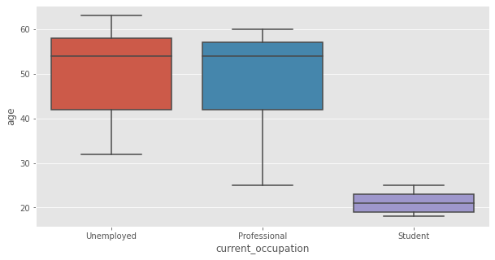

```python
plt.figure(figsize = (10, 5))

sns.boxplot(data["current_occupation"], data["age"])

plt.show()
```

```python
data.groupby(["current_occupation"])["age"].describe()
```

| current_occupation | count | mean | std | min | 25% | 50% | 75% | max |
| --- | --- | --- | --- | --- | --- | --- | --- | --- |
| Professional | 2616.0 | 49.347477 | 9.890744 | 25.0 | 42.0 | 54.0 | 57.0 | 60.0 |
| Student | 555.0 | 21.144144 | 2.001114 | 18.0 | 19.0 | 21.0 | 23.0 | 25.0 |
| Unemployed | 1441.0 | 50.140180 | 9.999503 | 32.0 | 42.0 | 54.0 | 58.0 | 63.0 |

**Observations**:

- The range of age for students is 18 to 25 years.
- The range of age for professionals is 25 to 60 years.
- The range of age for unemployed leads is 32 to 63 years.
- The average age of working professionals and unemployed leads is almost 50 years.

**Checking if the channels of the first interaction have an impact on the conversion of leads.**

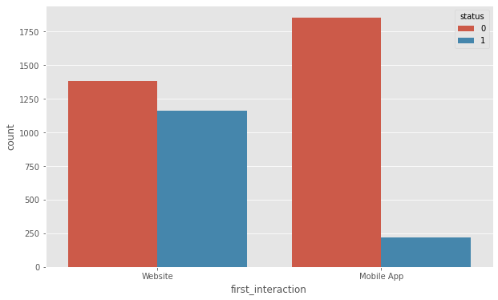

```python
plt.figure(figsize = (10, 6))

sns.countplot(x = 'first_interaction', hue = 'status', data = data)

plt.show()
```

**Observations**:

**Checking if spending more time on websites results in conversion.**

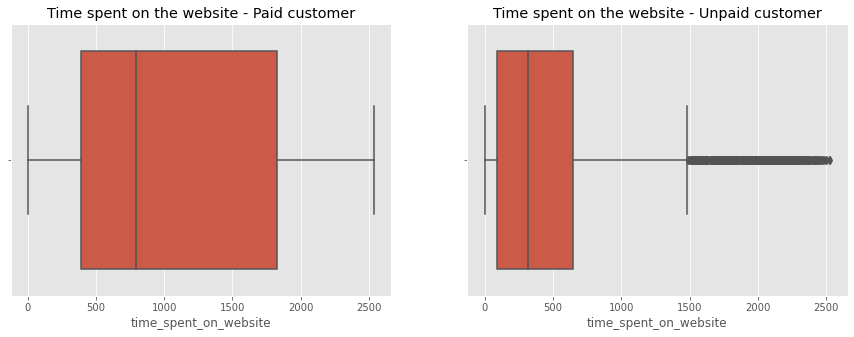

| status | count | mean | std | min | 25% | 50% | 75% | max |
| --- | --- | --- | --- | --- | --- | --- | --- | --- |
| 0 | 3235.0 | 577.420711 | 676.340484 | 0.0 | 88.0 | 317.0 | 646.0 | 2531.0 |
| 1 | 1377.0 | 1068.397967 | 780.856643 | 0.0 | 390.0 | 789.0 | 1829.0 | 2537.0 |

```python
plt.figure(figsize = (15, 5))
plt.subplot(121)
sns.boxplot(data=data[data.status==1], x = 'time_spent_on_website').set(title='Time spent on the website - Paid customer')
plt.subplot(122)
sns.boxplot(data=data[data.status==0], x = 'time_spent_on_website').set(title='Time spent on the website - Unpaid customer')
plt.show()
data.groupby(["status"])['time_spent_on_website'].describe()
```

**Observations**:

**Checking if the profile completion level has an impact on lead coversion**

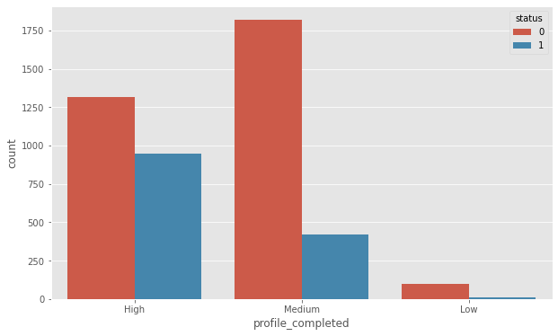

```python
plt.figure(figsize = (10, 6))

sns.countplot(x = 'profile_completed', hue = 'status', data = data)

plt.show()
```

**Observations**:

- The leads whose profile completion level is high converted more in comparison to other levels of profile completion.
- The medium and low levels of profile completion saw comparatively very less conversions.
- The high level of profile completion might indicate a lead's intent to pursue the course which results in high conversion.

**Checking how referrals impact lead conversion status.**

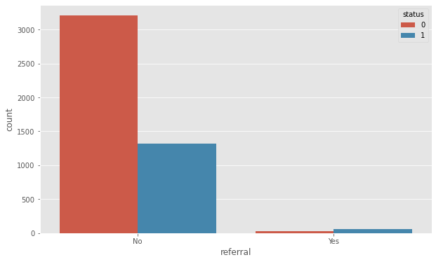

```python
plt.figure(figsize = (10, 6))

sns.countplot(x = 'referral', hue = 'status', data = data)

plt.show()
```

**Observations**:

- There are a very less number of referrals but the conversion is high.
- Company should try to get more leads through referrals by promoting rewards for existing customer base when they refer someone.

2.5 Multivariate Analysis

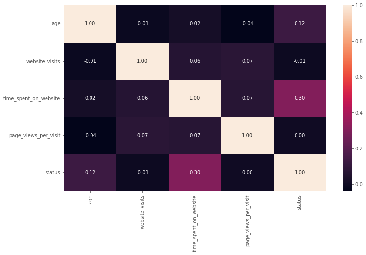

```python
plt.figure(figsize = (12, 7))

sns.heatmap(data[num_cols].corr(), annot = True, fmt = '.2f')

plt.show()
```

**Observations**:

- As seen before, **time_spent_on_website** has a moderate correlation with **status**.

2.6 Summary of Notes

3. Proposed Approach

3.1 Potential Techniques

- The following models are highlighted to be explored:
  - **Model 1)** Decision Tree with Default Hyperparameters.
  - **Model 2)** Decision Tree with Tuned Hyperparameters.
  - **Model 3)** Random Forest with Default Hyperparameters.
  - **Model 4)** Random Forest with Tuned Hyperparameters.

3.2 Overall solution design

- In order to establish the solution design, the original dataset will be brake down into two parts: Training Set and Test Set.
  - Training set: 70% of the data.
  - Test set: 30% of the data.
- All models will be explored using only the Training Set while the Test Set will be used to access their performances.

3.3 Measures of success

**Model can make wrong predictions as:**

1. Predicting a lead will not be converted to a paid customer but, in reality, the lead would have converted to a paid customer.
2. Predicting a lead will be converted to a paid customer but, in reality, the lead would have not converted to a paid customer.
- If we predict that a lead will not get converted and the lead would have converted then the company will lose a potential customer.
- If we predict that a lead will get converted and the lead doesn't get converted the company might lose resources by nurturing false-positive cases.

As losing a potential customer is a greater loss for the organization, company would want `Recall` to be maximized. The greater the Recall score, higher the chances of minimizing False Negatives.

4. Model Building

4.1 Data Preparation

**Separating the target variable from other variables**

```python
# Separating the target variable and other variables
X = data.drop(columns = 'status')

Y = data['status']
```

```python
# Creating dummy variables, drop_first=True is used to avoid redundant variables
X = pd.get_dummies(X, drop_first = True)
```

```python
# Splitting the data into train and test sets
X_train, X_test, y_train, y_test = train_test_split(X, Y, test_size = 0.30, random_state = 1)
```

**Checking the shape of the train and test data**

```python
print("Shape of the training set: ", X_train.shape)

print("Shape of the test set: ", X_test.shape)

print("Percentage of classes in the training set:")

print(y_train.value_counts(normalize = True))

print("Percentage of classes in the test set:")

print(y_test.value_counts(normalize = True))
```

```
Shape of the training set:  (3228, 16)
Shape of the test set:  (1384, 16)
Percentage of classes in the training set:
0    0.704151
1    0.295849
Name: status, dtype: float64
Percentage of classes in the test set:
0    0.695087
1    0.304913
Name: status, dtype: float64
```

4.2 Model Evaluation Function

```python
#creating metric function
def metrics_score(actual, predicted):
    print(classification_report(actual, predicted))
    cm = confusion_matrix(actual, predicted)
    plt.figure(figsize=(8,5))
    sns.heatmap(cm, annot=True,  fmt='.2f', xticklabels=['Eligible', 'Not Eligible'], yticklabels=['Eligible', 'Not Eligible'])
    plt.ylabel('Actual')
    plt.xlabel('Predicted')
    plt.show()
```

5. Decision Tree (DT) Model

5.1 DT with Default Hiperparameters

**Defining Decision tree model**

```python
# Fitting the decision tree classifier on the training data
d_tree = DecisionTreeClassifier(class_weight = {0: 0.70, 1: 0.30}, random_state = 7)

d_tree.fit(X_train, y_train)
```

```
DecisionTreeClassifier(class_weight={0: 0.7, 1: 0.3}, random_state=7)
```

**Let's check the performance on the training data**

```
              precision    recall  f1-score   support

           0       1.00      1.00      1.00      2273
           1       1.00      1.00      1.00       955

    accuracy                           1.00      3228
   macro avg       1.00      1.00      1.00      3228
weighted avg       1.00      1.00      1.00      3228
```

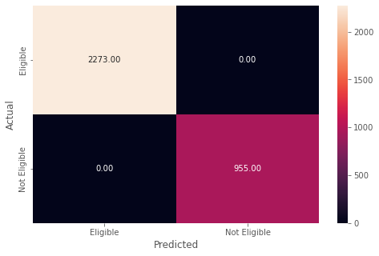

```python
y_pred_train1 = d_tree.predict(X_train)
metrics_score(y_train, y_pred_train1)
```

**Observations**:

- The Decision tree is giving a **100% score for all metrics on the training dataset.**

**Let's check the performance on test data to see if the model is overfitting.**

```
              precision    recall  f1-score   support

           0       0.87      0.87      0.87       962
           1       0.70      0.69      0.70       422

    accuracy                           0.82      1384
   macro avg       0.78      0.78      0.78      1384
weighted avg       0.81      0.82      0.81      1384
```

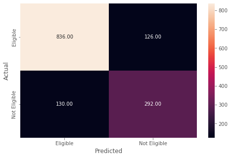

```python
y_pred_test1 = d_tree.predict(X_test)
metrics_score(y_test, y_pred_test1)
```

**Observations**:

- The Decision Tree works well on the training data but **not so well on the test data** as the recall of class 1 is 69\% in comparison to 100\% for the training dataset, i.e., the Decision Tree is overfitting the training data.
- The precision on the test data suggests that there's a ~30% chance that the model will predict that a lead is going to be converted even though it would not, and **the company might lose resources by nurturing false-positive cases.**

**Checking feature importance**

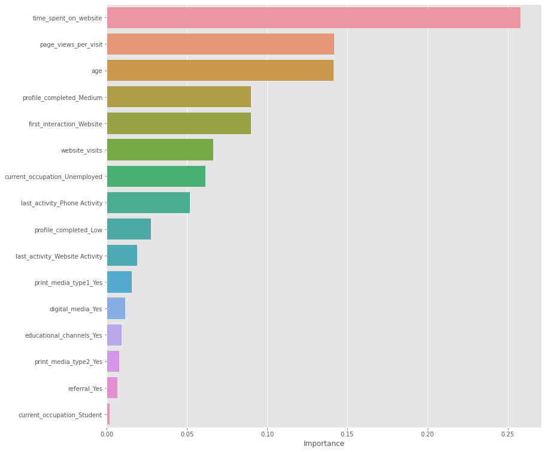

```python
importances = d_tree.feature_importances_

columns = X.columns

importance_df = pd.DataFrame(importances, index = columns, columns = ['Importance']).sort_values(by = 'Importance', ascending = False)

plt.figure(figsize = (13, 13))

sns.barplot(importance_df.Importance,importance_df.index);
```

5.2 DT with Tuned Hiperparameters

**Using GridSearch for Hyperparameter Tuning**

- Hyperparameter tuning is tricky in the sense that **there is no direct way to calculate how a change in the hyperparameter value will reduce the loss of your model**, so we usually resort to experimentation. We'll use Grid search to perform hyperparameter tuning.
- **Grid search is a tuning technique that attempts to compute the optimum values of hyperparameters.**
- **It is an exhaustive search** that is performed on the specific parameter values of a model.
- The parameters of the estimator/model used to apply these methods are **optimized by cross-validated grid-search** over a parameter grid.

**Criterion{“gini”, “entropy”}**

The function is to measure the quality of a split. Supported criteria are “gini” for the Gini impurity and “entropy” for the information gain.

**max_depth**

The maximum depth of the tree. If None, then nodes are expanded until all leaves are pure or until all leaves contain less than min_samples_split samples.

**min_samples_leaf**

The minimum number of samples is required to be at a leaf node. A split point at any depth will only be considered if it leaves at least min_samples_leaf training samples in each of the left and right branches. This may have the effect of smoothing the model, especially in regression.

**Let's try hyperparameter tuning using GridSearchCV to find the optimal max_depth** to reduce overfitting of the model. We can tune some other hyperparameters as well.

```python
# Choose the type of classifier
d_tree_tuned = DecisionTreeClassifier(random_state = 7, class_weight = {0: 0.3, 1: 0.7})

# Grid of parameters to choose from
parameters = {'max_depth': np.arange(2, 10),
              'criterion': ['gini', 'entropy'],
              'min_samples_leaf': [5, 10, 20, 25]
             }

# Type of scoring used to compare parameter combinations - recall score for class 1
scorer = metrics.make_scorer(recall_score, pos_label = 1)

# Run the grid search
grid_obj = GridSearchCV(d_tree_tuned, parameters, scoring = scorer, cv = 5)

grid_obj = grid_obj.fit(X_train, y_train)

# Set the classifier to the best combination of parameters
d_tree_tuned = grid_obj.best_estimator_

# Fit the best algorithm to the data
d_tree_tuned.fit(X_train, y_train)
```

```
DecisionTreeClassifier(class_weight={0: 0.3, 1: 0.7}, criterion='entropy',
                       max_depth=3, min_samples_leaf=5, random_state=7)
```

#### Checking the performance on the train dataset

```
              precision    recall  f1-score   support

           0       0.94      0.77      0.85      2273
           1       0.62      0.88      0.73       955

    accuracy                           0.80      3228
   macro avg       0.78      0.83      0.79      3228
weighted avg       0.84      0.80      0.81      3228
```

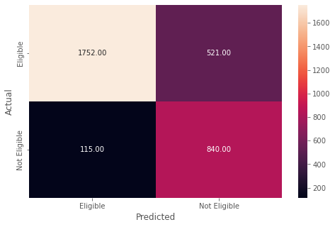

```python
# Checking performance on the training data
y_pred_train2 = d_tree_tuned.predict(X_train)

metrics_score(y_train, y_pred_train2)
```

**Observations**:

- The performance on the training set has gone down significantly when compared to the previous model (default values of hyperparameters).
- This makes sense because the previous model was overfitting and now we are trying to reduce it.

#### Checking the performance on the test dataset

```
              precision    recall  f1-score   support

           0       0.93      0.77      0.84       962
           1       0.62      0.86      0.72       422

    accuracy                           0.80      1384
   macro avg       0.77      0.82      0.78      1384
weighted avg       0.83      0.80      0.80      1384
```

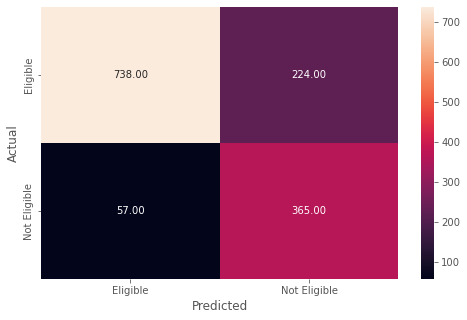

```python
# Checking performance on the testing data
y_pred_test2 = d_tree_tuned.predict(X_test)

metrics_score(y_test, y_pred_test2)
```

**Observations**:

- The tuned model is performing better in comparison to the model with default values of hyperparameters.
  - Accuracy:
    - Non-tuned model: 82%
    - Tuned model: 80%
  - Recall:
    - Non-tuned model: 78%
    - Tuned model: 82%
- Even though the accuracy of the tuned model is performing worse in the tuned model(80% against 82% of the non-tuned model), the Recal has improved (82% against 78% of the non-tuned model).
- As maximizing Recal is more important in this problem, we can state that the tuned model is better than the non-tuned model (model with default values of hyperparameters).

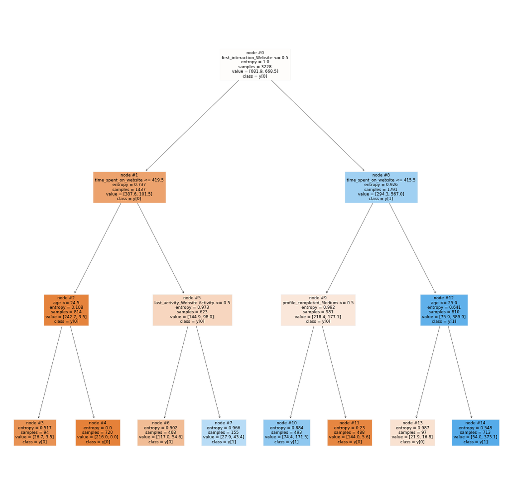

```python
features = list(X.columns)

plt.figure(figsize = (20, 20))

tree.plot_tree(d_tree_tuned, feature_names = features, filled = True, fontsize = 9, node_ids = True, class_names = True)

plt.show()
```

**Note:**

**Observations**:

- Leads who did the first interaction with ExtraaLearn via 'Website' have more chance of being converted.
- The more time spent on the website, the greater the chances of leads being converted.
- Leads who spent more time on website and that have an age greater than 25 have even more chances to be converted.
- Young leads who spend less time on website and that did the first interaction with Extra Learn via other than the Website, have very low chances to be converted.
- In contrast, the leads who did the first interaction with Extra Learn via other than the Website, but that in a way were directed to the website as last activity, have a chance to be converted.

**Checking feature importance**

```python
# Importance of features in the tree building

print (pd.DataFrame(d_tree_tuned.feature_importances_, columns = ["Imp"], index = X_train.columns).sort_values(by = 'Imp', ascending = False))
```

```
                                     Imp
time_spent_on_website           0.348142
first_interaction_Website       0.327181
profile_completed_Medium        0.239274
age                             0.063893
last_activity_Website Activity  0.021511
website_visits                  0.000000
page_views_per_visit            0.000000
current_occupation_Student      0.000000
current_occupation_Unemployed   0.000000
profile_completed_Low           0.000000
last_activity_Phone Activity    0.000000
print_media_type1_Yes           0.000000
print_media_type2_Yes           0.000000
digital_media_Yes               0.000000
educational_channels_Yes        0.000000
referral_Yes                    0.000000
```

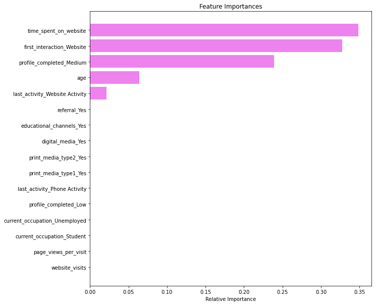

```python
# Plotting the feature importance
importances = d_tree_tuned.feature_importances_

indices = np.argsort(importances)

plt.figure(figsize = (10, 10))

plt.title('Feature Importances')

plt.barh(range(len(indices)), importances[indices], color = 'violet', align = 'center')

plt.yticks(range(len(indices)), [features[i] for i in indices])

plt.xlabel('Relative Importance')

plt.show()
```

**Observations**:

- **Time spent on the website and first_interaction_website are the most important features** **followed by profile_completed, age, and last_activity**.
- **The rest of the variables have no impact in this model, while deciding whether a lead will be converted or not**.

Now, let's build another model - **a random forest classifier.**

6. Random Forest (RF) Model

**Random Forest is a bagging algorithm where the base models are Decision Trees.** Samples are taken from the training data and on each sample a decision tree makes a prediction.

**The results from all the decision trees are combined together and the final prediction is made using voting or averaging.**

6.1 RF with Default Hiperparameters

**Defining Random forest CLassifier**

```python
rf_estimator = RandomForestClassifier(class_weight = {0: 0.70, 1: 0.30}, random_state = 7)
rf_estimator.fit(X_train, y_train)
```

```
RandomForestClassifier(class_weight={0: 0.7, 1: 0.3}, random_state=7)
```

**Checking the performance on the train dataset**

```
              precision    recall  f1-score   support

           0       1.00      1.00      1.00      2273
           1       1.00      1.00      1.00       955

    accuracy                           1.00      3228
   macro avg       1.00      1.00      1.00      3228
weighted avg       1.00      1.00      1.00      3228
```

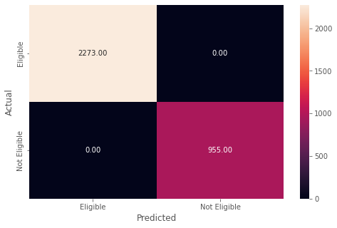

```python
y_pred_train3 = rf_estimator.predict(X_train)
metrics_score(y_train, y_pred_train3)
```

**Observations**:

- The Random Forest is also giving a 100% score for all metrics on the training dataset.

**Checking performance on the test dataset**

```
              precision    recall  f1-score   support

           0       0.88      0.92      0.90       962
           1       0.80      0.72      0.76       422

    accuracy                           0.86      1384
   macro avg       0.84      0.82      0.83      1384
weighted avg       0.86      0.86      0.86      1384
```

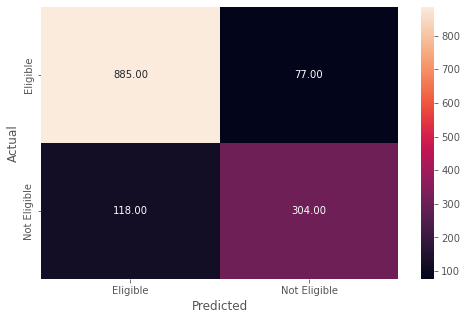

```python
y_pred_test3 = rf_estimator.predict(X_test)
metrics_score(y_test, y_pred_test3)
```

**Observations**:

- The Random Forest seems to be overfitting the training data. The recall on the training data is 1, while the recall on the test data is only 0.72 for class 1.
- Average precision has gone down significantly from 100% in the training data set to 84% in the test data set.

**Feature importance of the Random Forest**

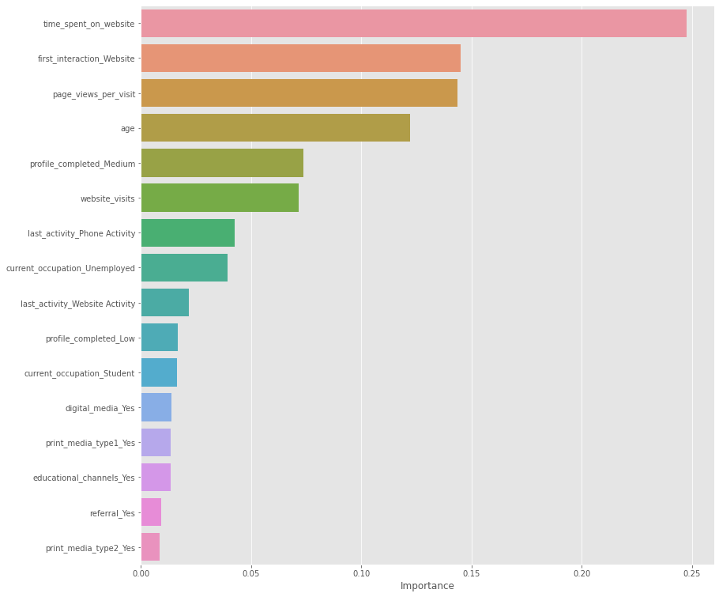

```python
importances = rf_estimator.feature_importances_

columns = X.columns

importance_df = pd.DataFrame(importances, index = columns, columns = ['Importance']).sort_values(by = 'Importance', ascending = False)

plt.figure(figsize = (13, 13))

sns.barplot(importance_df.Importance, importance_df.index);
```

6.2 RF with Tuned Hyperparameters

- Hyperparameter tuning is tricky in the sense that **there is no direct way to calculate how a change in the hyperparameter value will reduce the loss of your model**, so we usually resort to experimentation. We'll use Grid search to perform hyperparameter tuning.
- **Grid search is a tuning technique that attempts to compute the optimum values of hyperparameters.**
- **It is an exhaustive search** that is performed on the specific parameter values of a model.
- The parameters of the estimator/model used to apply these methods are **optimized by cross-validated grid-search** over a parameter grid.

**n_estimators**: The number of trees in the forest.

**min_samples_split**: The minimum number of samples required to split an internal node:

**min_samples_leaf**: The minimum number of samples required to be at a leaf node.

**max_features{“auto”, “sqrt”, “log2”, 'None'}**: The number of features to consider when looking for the best split.

- If “auto”, then max_features=sqrt(n_features).
- If “sqrt”, then max_features=sqrt(n_features) (same as “auto”).
- If “log2”, then max_features=log2(n_features).
- If None, then max_features=n_features.

Let's try **tuning some of the important hyperparameters of the Random Forest Classifier**.

We will **not** tune the `criterion` hyperparameter as we know from hyperparameter tuning for decision trees that `entropy` is a better splitting criterion for this data.

```python
# Choose the type of classifier
rf_estimator_tuned = RandomForestClassifier(criterion = "entropy", random_state = 7)

# Grid of parameters to choose from
parameters = {"n_estimators": [110, 120],
    "max_depth": [6, 7],
    "min_samples_leaf": [20, 25],
    "max_features": [0.8, 0.9],
    "max_samples": [0.9, 1],
    "class_weight": ["balanced",{0: 0.3, 1: 0.7}]
             }

# Type of scoring used to compare parameter combinations - recall score for class 1
scorer = metrics.make_scorer(recall_score, pos_label = 1)

# Run the grid search on the training data using scorer=scorer and cv=5
grid_obj = GridSearchCV(rf_estimator_tuned, parameters, scoring = scorer, cv = 5)

grid_obj = grid_obj.fit(X_train, y_train)

# Save the best estimator to variable rf_estimator_tuned
rf_estimator_tuned = grid_obj.best_estimator_

#Fit the best estimator to the training data
rf_estimator_tuned.fit(X_train, y_train)
```

```
RandomForestClassifier(class_weight='balanced', criterion='entropy',
                       max_depth=6, max_features=0.8, max_samples=0.9,
                       min_samples_leaf=25, n_estimators=120, random_state=7)
```

#### Checking the performance on the train dataset

```
              precision    recall  f1-score   support

           0       0.94      0.83      0.88      2273
           1       0.68      0.87      0.76       955

    accuracy                           0.84      3228
   macro avg       0.81      0.85      0.82      3228
weighted avg       0.86      0.84      0.84      3228
```

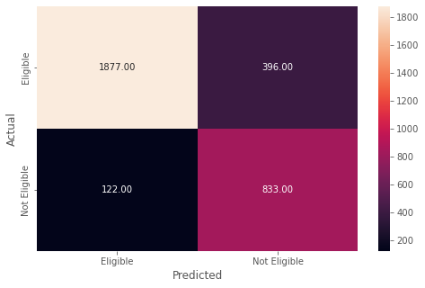

```python
# Checking performance on the training data
y_pred_train4 = rf_estimator_tuned.predict(X_train)

metrics_score(y_train, y_pred_train4)
```

**Observations:**

- The Random Forest tuned model is performing relativelly well in the training dataset, with 87\% of Recall for class 1, even with a small precision of 68\%.

#### Checking the performance on the test dataset

```
              precision    recall  f1-score   support

           0       0.93      0.83      0.87       962
           1       0.68      0.85      0.76       422

    accuracy                           0.83      1384
   macro avg       0.80      0.84      0.82      1384
weighted avg       0.85      0.83      0.84      1384
```

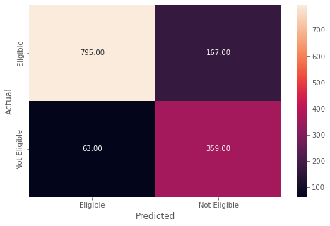

```python
y_pred_test4 = rf_estimator_tuned.predict(X_test)
metrics_score(y_test, y_pred_test4)
```

**Observations:**

- The Random Forest tuned model shows a good performance on the test dataset.
  - Recall class 1: 85\% (Decision tree is 69\%, tuned decision tree is 86\%, and non tuned random forest is 72\%)
  - Precision class 1: 68\% (Decision tree is 70\%, tuned decision tree is 62\%, and non tuned random forest is 80\%)
  - Accuracy: 83\% (Decision tree is 82\%, tuned decision tree is 80\%, and non tuned random forest is 86\%)
  - Average Recall: 84\% (Decision tree is 78\%, tuned decision tree is 82\%, and non tuned random forest is 82\%)
- As maximizing average recall is more important, the Random Forest tuned model is the best-performing one among all the models so far.

**One of the drawbacks of ensemble models is that we lose the ability to obtain an interpretation of the model. We cannot observe the decision rules for random forests the way we did for decision trees. So, let's just check the feature importance of the model.**

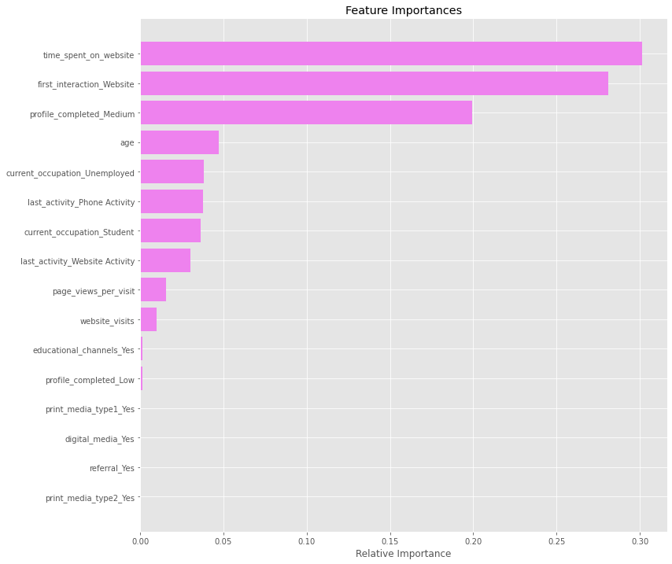

```python
importances = rf_estimator_tuned.feature_importances_

indices = np.argsort(importances)

feature_names = list(X.columns)

plt.figure(figsize = (12, 12))

plt.title('Feature Importances')

plt.barh(range(len(indices)), importances[indices], color = 'violet', align = 'center')

plt.yticks(range(len(indices)), [feature_names[i] for i in indices])

plt.xlabel('Relative Importance')

plt.show()
```

**Observations:**

- Similar to the decision tree model, **time spent on website, first_interaction_website, profile_completed, and age are the top four features** that help distinguish between not converted and converted leads.
- Unlike the decision tree, **the random forest gives some importance to other variables like occupation, page_views_per_visit, as well.** This implies that the random forest is giving importance to more factors in comparison to the decision tree.

7. Comparing Model Performances

```python
models = ['DT with Default Hyperparameters', 'DT with Tuned Hyperparameters', 'RF Default Hyperparameters', 'RF with Tuned Hyperparameters']

Y_PRED = [y_pred_test1, y_pred_test2, y_pred_test3, y_pred_test4]

Y_TRUE = [y_test, y_test, y_test, y_test]

Res = np.empty((4,4),dtype=float)

for i in range(len(Y_PRED)):
    Res[i,:] = [classification_report(Y_TRUE[i], Y_PRED[i], output_dict=True)['macro avg']['f1-score'],
               classification_report(Y_TRUE[i], Y_PRED[i], output_dict=True)['macro avg']['recall'],
               classification_report(Y_TRUE[i], Y_PRED[i], output_dict=True)['macro avg']['precision'],
               classification_report(Y_TRUE[i], Y_PRED[i], output_dict=True)['accuracy']]
Res = Res*100
```

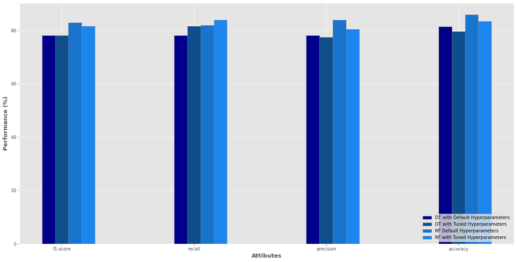

```python
barWidth = 0.1
fig = plt.subplots(figsize =(20, 10))

# Set position of bar on X axis
br1 = np.arange(len(Res[0]))
br2 = [x + barWidth for x in br1]
br3 = [x + barWidth for x in br2]
br4 = [x + barWidth for x in br3]


# Make the plot
plt.bar(br1, Res[0], color ='#00008B', width = barWidth, edgecolor ='grey', label = models[0])
plt.bar(br2, Res[1], color ='#104E8B', width = barWidth, edgecolor ='grey', label = models[1])
plt.bar(br3, Res[2], color ='#1874CD', width = barWidth, edgecolor ='grey', label = models[2])
plt.bar(br4, Res[3], color ='#1C86EE', width = barWidth, edgecolor ='grey', label = models[3])

# Adding Xticks
plt.xlabel('Attibutes', fontweight ='bold', fontsize = 13)
plt.ylabel('Performance (%)', fontweight ='bold', fontsize = 13)
plt.xticks([r + barWidth for r in range(len(Res[0]))],['f1-score', 'recall', 'precision', 'accuracy'])
plt.legend(loc='lower right')
plt.show()
```

8. Conclusions and Busines Recomendations

### **Business Recommendations**

- In conclusion, the leads who interacted through websites have more chances to be converted to paid customers, while only a small number of leads, who interacted through mobile app, were converted. Therefore, the organization should focus the attention of customers in the website while also enticing them to provide their full profiles.